# Introduction

Support Vector Machine is a supervised Machine Learning algorithm widely used for solving different machine learning problems. Given a dataset, the algorithm tries to divide the data using hyperplanes and then makes the predictions. SVM is a non-probabilistic linear classifier. While other classifiers, when classifying, predict the probability of a data point to belong to one group or the another, SVM directly says to which group the datapoint belongs to without using any probability calculation.

## Understanding the Mathematics involved

Let’s take the example of the following dataset and see how can we divide the data into appropriate groups.

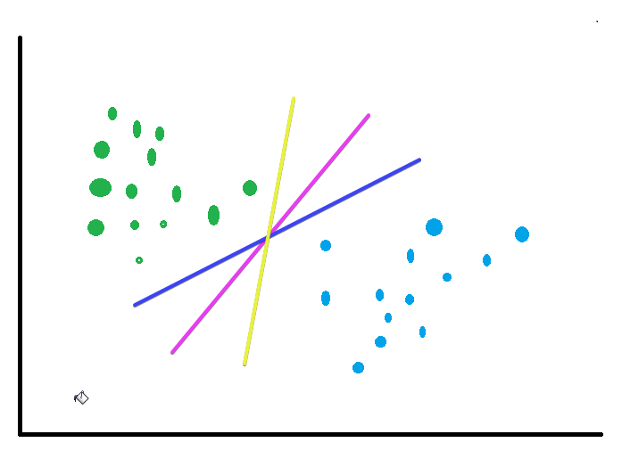

We can see that there are two groups of data. The question is how to divide these points into two groups. It can be done using any of the three lines. Or, for that purpose, there can be an infinite number of straight lines that can divide these points into two classes. Now, which line to choose? SVM solves this problem using the maximum margin as shown

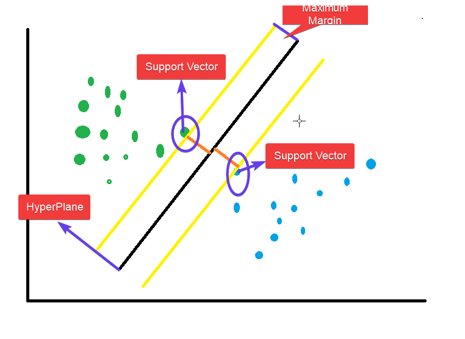

The black line in the middle is the optimum classifier. This line is drawn to maximise the distance of the classifier line from the nearest points in the two classes. It is also called a **hyperplane** in terms of SVM. A *Hyperplane* is an n-1 dimensional plane which optimally divides the data of n dimensions. Here, as we have only a 2-D data, so the hyperplane can be represented using one dimension only. Hence, the hyperplane is a line here. The two points (highlighted with circles) which are on the yellow lines, they are called the **support vectors**. As it is a 2-D figure, they are points. In a multi-dimensional space, they will be vectors, and hence, the name- support vector machine as the algorithm creates the optimum classification line by maximising its distance from the two support vectors.

When the data is not linearly separable, then to create a hyperplane to separate data into different groups, the SVM algorithm needs to perform computations in a higher-dimensional space. But the introduction of new dimensions makes the computations for the SVMs more intensive, which impacts the algorithm performance. To rectify this, mathematicians came up with the approach of Kernel methods. Kernel methods use kernel functions available in mathematics. The unique feature of a kernel function is to compute in a higher-dimensional space without calculating the new coordinates in that higher dimension. It implicitly uses predefined mathematical functions to do operations on the existing points which mimic the computation in a higher-dimensional space without adding to the computation cost as they are not actually calculating the coordinates in the higher dimension thereby avoiding the computation of calculating distances from the newly computed points. This is called the kernel trick.

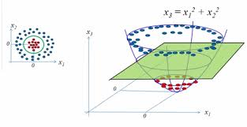

Image: bogotobogo.com

In the left diagram above, we have a non-linear distribution of data as we can not classify a data using a linear equation. To solve this problem, we can project the points in a 3-dimensional space and then derive a plane which divides the data into two parts. In theory, that’s what a kernel function does without computing the additional coordinates for the higher dimension.

## Python Implementation

```python
import pandas as pd
import matplotlib.pyplot as plt
```

```python
df=pd.read_csv('winequality-red.csv')
```

```python
df.head()
```

|  | fixed acidity | volatile acidity | citric acid | residual sugar | chlorides | free sulfur dioxide | total sulfur dioxide | density | pH | sulphates | alcohol | quality |
| --- | --- | --- | --- | --- | --- | --- | --- | --- | --- | --- | --- | --- |
| 0 | 7.4 | 0.70 | 0.00 | 1.9 | 0.076 | 11.0 | 34.0 | 0.9978 | 3.51 | 0.56 | 9.4 | 5 |
| 1 | 7.8 | 0.88 | 0.00 | 2.6 | 0.098 | 25.0 | 67.0 | 0.9968 | 3.20 | 0.68 | 9.8 | 5 |
| 2 | 7.8 | 0.76 | 0.04 | 2.3 | 0.092 | 15.0 | 54.0 | 0.9970 | 3.26 | 0.65 | 9.8 | 5 |
| 3 | 11.2 | 0.28 | 0.56 | 1.9 | 0.075 | 17.0 | 60.0 | 0.9980 | 3.16 | 0.58 | 9.8 | 6 |
| 4 | 7.4 | 0.70 | 0.00 | 1.9 | 0.076 | 11.0 | 34.0 | 0.9978 | 3.51 | 0.56 | 9.4 | 5 |

```python
df.isna().sum()
```

```
fixed acidity           0
volatile acidity        0
citric acid             0
residual sugar          0
chlorides               0
free sulfur dioxide     0
total sulfur dioxide    0
density                 0
pH                      0
sulphates               0
alcohol                 0
quality                 0
dtype: int64
```

As the data consists of values which differ a lot in magnitude, they need to be brought to the same scale. It's done using the standard scalar.

```python
from sklearn.preprocessing import StandardScaler
scaler= StandardScaler()
new_data=scaler.fit_transform(df.drop(labels=['quality'],axis=1))
```

```python
df.columns
```

```
Index(['fixed acidity', 'volatile acidity', 'citric acid', 'residual sugar',
       'chlorides', 'free sulfur dioxide', 'total sulfur dioxide', 'density',
       'pH', 'sulphates', 'alcohol', 'quality'],
      dtype='object')
```

```python
columns=['fixed acidity', 'volatile acidity', 'citric acid', 'residual sugar',
       'chlorides', 'free sulfur dioxide', 'total sulfur dioxide', 'density',
       'pH', 'sulphates', 'alcohol']
```

```python
new_df=pd.DataFrame(data=new_data,columns=columns)
```

```python
new_df.head()
```

|  | fixed acidity | volatile acidity | citric acid | residual sugar | chlorides | free sulfur dioxide | total sulfur dioxide | density | pH | sulphates | alcohol |
| --- | --- | --- | --- | --- | --- | --- | --- | --- | --- | --- | --- |
| 0 | -0.528360 | 0.961877 | -1.391472 | -0.453218 | -0.243707 | -0.466193 | -0.379133 | 0.558274 | 1.288643 | -0.579207 | -0.960246 |
| 1 | -0.298547 | 1.967442 | -1.391472 | 0.043416 | 0.223875 | 0.872638 | 0.624363 | 0.028261 | -0.719933 | 0.128950 | -0.584777 |
| 2 | -0.298547 | 1.297065 | -1.186070 | -0.169427 | 0.096353 | -0.083669 | 0.229047 | 0.134264 | -0.331177 | -0.048089 | -0.584777 |
| 3 | 1.654856 | -1.384443 | 1.484154 | -0.453218 | -0.264960 | 0.107592 | 0.411500 | 0.664277 | -0.979104 | -0.461180 | -0.584777 |
| 4 | -0.528360 | 0.961877 | -1.391472 | -0.453218 | -0.243707 | -0.466193 | -0.379133 | 0.558274 | 1.288643 | -0.579207 | -0.960246 |

As there are no missing values, we don't need to do data imputation.

```python
x=new_df
y=df['quality']
```

```python
from  sklearn.model_selection import train_test_split
train_x,test_x,train_y,test_y=train_test_split(x,y,test_size=0.33, random_state=42)
```

```python
from sklearn.svm import SVC
```

```python
model=SVC()
model.fit(train_x,train_y)
```

```
SVC(C=1.0, break_ties=False, cache_size=200, class_weight=None, coef0=0.0,
    decision_function_shape='ovr', degree=3, gamma='scale', kernel='rbf',
    max_iter=-1, probability=False, random_state=None, shrinking=True,
    tol=0.001, verbose=False)
```

```python
model.predict(test_x)
```

```python
from sklearn.metrics import accuracy_score
```

```python
accuracy_score(test_y,model.predict(test_x))
```

```
0.6003787878787878
```

As observed, the accuracy of the model is quite low. We need to implement the grid search approach to optimize the parameters to give the best accuracy.

#### Implementing Grid Search

```python
from sklearn.model_selection import GridSearchCV
```

```python
param_grid={'C':[0.1,1,10,50,100,500],'gamma':[1,0.5,0.1,0.01,0.001]}
```

```python
grid= GridSearchCV(SVC(),param_grid, verbose=3, n_jobs=-1)
```

```python
grid.fit(train_x,train_y)
```

```python
grid.best_params_
```

```
{'C': 10, 'gamma': 1}
```

```python
model_new=SVC(C=10, gamma=1)
model_new.fit(train_x,train_y)
```

```
SVC(C=10, break_ties=False, cache_size=200, class_weight=None, coef0=0.0,
    decision_function_shape='ovr', degree=3, gamma=1, kernel='rbf', max_iter=-1,
    probability=False, random_state=None, shrinking=True, tol=0.001,
    verbose=False)
```

```python
accuracy_score(test_y,model_new.predict(test_x))
```

```
0.6268939393939394
```

## Support Vector Regression

Let’s talk about Linear Regression first. How to determine the best fit line? The idea is to create a line which minimises the total residual error. The SVR approach is a bit different. Instead of trying to minimise the error, SVR focuses on keeping the error in a fixed range. This approach can be explained using three lines. The first line is the best fit regressor line, and the other two lines are the bordering ones which denote the range of error.

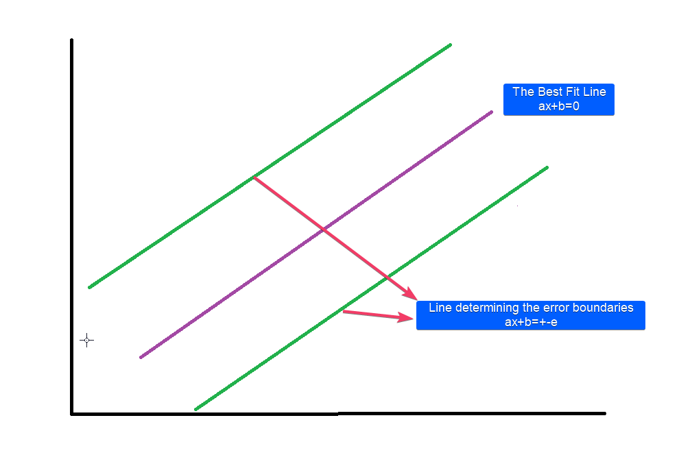

What does this mean? It means that we are going to consider the points inside this ± error boundary only for preparing our model. In other words, the best fit line(or the hyperplane) will be the line which goes through the maximum number of data points and the error boundaries are chosen to ensure maximum inclusion. This error term can be customized using the '*epsilon*' parameter defined for the scikit-learn SVR implementation.

## Python Implementation

```python
# necessary Imports
import pandas as pd
import matplotlib.pyplot as plt
% matpllotlib inline
```

```
UsageError: Line magic function `%` not found.
```

```python
df= pd.read_csv('Admission_Prediction.csv')
```

```python
df.head()
```

|  | Serial No. | GRE Score | TOEFL Score | University Rating | SOP | LOR | CGPA | Research | Chance of Admit |
| --- | --- | --- | --- | --- | --- | --- | --- | --- | --- |
| 0 | 1 | 337.0 | 118.0 | 4.0 | 4.5 | 4.5 | 9.65 | 1 | 0.92 |
| 1 | 2 | 324.0 | 107.0 | 4.0 | 4.0 | 4.5 | 8.87 | 1 | 0.76 |
| 2 | 3 | NaN | 104.0 | 3.0 | 3.0 | 3.5 | 8.00 | 1 | 0.72 |
| 3 | 4 | 322.0 | 110.0 | 3.0 | 3.5 | 2.5 | 8.67 | 1 | 0.80 |
| 4 | 5 | 314.0 | 103.0 | 2.0 | 2.0 | 3.0 | 8.21 | 0 | 0.65 |

```python
df.isna().sum()
```

```
Serial No.            0
GRE Score            15
TOEFL Score          10
University Rating    15
SOP                   0
LOR                   0
CGPA                  0
Research              0
Chance of Admit       0
dtype: int64
```

As we can see, there are some column with missing values. we need to impute those missing values.

```python
df['GRE Score'].fillna(df['GRE Score'].mean(),inplace=True)
df['TOEFL Score'].fillna(df['TOEFL Score'].mean(),inplace=True)
df['University Rating'].fillna(df['University Rating'].mode()[0],inplace=True)
```

```python
# seeing that after imputation no column has missing values
df.isna().sum()
```

```
Serial No.           0
GRE Score            0
TOEFL Score          0
University Rating    0
SOP                  0
LOR                  0
CGPA                 0
Research             0
Chance of Admit      0
dtype: int64
```

```python
x=df.drop(['Chance of Admit','Serial No.'],axis=1)
y=df['Chance of Admit']
columns=x.columns
```

```python
from sklearn.model_selection import train_test_split
```

```python
train_x,test_x,train_y,test_y=train_test_split(x,y,test_size=0.33, random_state=33)
```

```python
from sklearn.svm import SVR
svr= SVR(C=10)
```

```python
svr.fit(train_x, train_y)
```

```
SVR(C=10, cache_size=200, coef0=0.0, degree=3, epsilon=0.1, gamma='scale',
    kernel='rbf', max_iter=-1, shrinking=True, tol=0.001, verbose=False)
```

```python
from sklearn.metrics import r2_score
score= r2_score(test_y,svr.predict(test_x))
score
```

```
0.7340987165302327
```

```python
from sklearn.model_selection import GridSearchCV
param_grid={'C':[0.1,1,10,50,100,500],'gamma':[1,0.5,0.1,0.01,0.001] }
grid= GridSearchCV(SVR(),param_grid, verbose=3)
```

```python
grid.fit(train_x,train_y)
```

```python
grid.best_estimator_
```

```
SVR(C=50, cache_size=200, coef0=0.0, degree=3, epsilon=0.1, gamma=0.001,
    kernel='rbf', max_iter=-1, shrinking=True, tol=0.001, verbose=False)
```

```python
svr_new=SVR(C=50, cache_size=200, coef0=0.0, degree=3, epsilon=0.1, gamma=0.001,
    kernel='rbf', max_iter=-1, shrinking=True, tol=0.001, verbose=False)
```

```python
svr_new.fit(train_x, train_y)
```

```
SVR(C=50, cache_size=200, coef0=0.0, degree=3, epsilon=0.1, gamma=0.001,
    kernel='rbf', max_iter=-1, shrinking=True, tol=0.001, verbose=False)
```

```python
score_new= r2_score(test_y,svr_new.predict(test_x))
score_new
```

```
0.7457021772643664
```

```python
# saving the model to the local file system
"""from joblib import dump, load
filename = 'test1.joblib'
dump(svr_new, filename) """
filename = 'finalized_model.pickle'
pickle.dump(svr_new, open(filename, 'wb'))
```

[output not shown]

Now this saved model file will be used for prediction. We'll create a Flask app for the same and deploy it to AWS.

```python
loaded_model = pickle.load(open(filename, 'rb'))
prediction=loaded_model.predict(([[320,120,5,5,5,10,1]]))
print(prediction[0])
```

```
0.9514405802107618
```

# Flask App

As we’ll expose the created model as a web API to be consumed by the client/client APIs, we’d do it using the flask framework. The flow of our flask app will be:

[figure not shown]

• Create the project structure, as shown below:

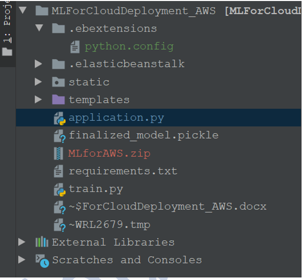

```python
# * Index.html

# {% extends 'base.html' %}

# {% block head %}

# <title>Search Page</title>
# <link rel="stylesheet" href="{{ url_for('static', filename='css/style.css') }}">
# {% endblock %}

# {% block body %}
# <div class="content">
#     <h1 style="text-align: center">Predict Your chances for Admission</h1>

#     <div class="form">
#         <form action="/predict" method="POST">
#             <input type="number" name="gre_score" id="gre_score" placeholder="GRE Score">
#             <input type="number" name="toefl_score" id="toefl_score" placeholder="TOEFL Score">
#             <input type="number" name="university_rating" id="university_rating" placeholder="University Rating">
#             <input type="number" name="sop" id="sop" placeholder="SOP Score">
#             <input type="number" name="lor" id="lor" placeholder="LOR Score">
#             <input type="number" name="cgpa" id="cgpa"placeholder="CGPA" step="any">
#             <select name="research" id="research">
#   <option value="yes">Yes</option>
#   <option value="no">No</option>
# </select>
#             <input type="submit" value="Predict">
#         </form>
#     </div>
# </div>
# {% endblock %}
```

```python
# * application.py

# # importing the necessary dependencies
# from flask import Flask, render_template, request,jsonify
# from flask_cors import CORS,cross_origin
# import pickle

# app = Flask(__name__) # initializing a flask app

# @app.route('/',methods=['GET'])  # route to display the home page
# @cross_origin()
# def homePage():
#     return render_template("index.html")

# @app.route('/predict',methods=['POST','GET']) # route to show the predictions in a web UI
# @cross_origin()
# def index():
#     if request.method == 'POST':
#         try:
#             #  reading the inputs given by the user
#             gre_score=float(request.form['gre_score'])
#             toefl_score = float(request.form['toefl_score'])
#             university_rating = float(request.form['university_rating'])
#             sop = float(request.form['sop'])
#             lor = float(request.form['lor'])
#             cgpa = float(request.form['cgpa'])
#             is_research = request.form['research']
#             if(is_research=='yes'):
#                 research=1
#             else:
#                 research=0
#             filename = 'finalized_model.pickle'
#             loaded_model = pickle.load(open(filename, 'rb')) # loading the model file from the storage
#             # predictions using the loaded model file
#             prediction=loaded_model.predict([[gre_score,toefl_score,university_rating,sop,lor,cgpa,research]])
#             print('prediction is', prediction)
#             # showing the prediction results in a UI
#             return render_template('results.html',prediction=round(100*prediction[0]))
#         except Exception as e:
#             print('The Exception message is: ',e)
#             return 'something is wrong.'
#     # return render_template('results.html')
#     else:
#         return render_template('index.html')



# if __name__ == "__main__":
#     #app.run(host='127.0.0.1', port=8001, debug=True)
#    app.run(debug=True) # running the app
```

```python
# * results.html

# •	<!DOCTYPE html>
# <html lang="en" >

# <head>
#   <meta charset="UTF-8">
#   <title>Review Page</title>

#     <link rel="stylesheet" href="https://cdnjs.cloudflare.com/ajax/libs/normalize/5.0.0/normalize.min.css">


#       <link rel="stylesheet" href="./style.css">
#     <link rel="stylesheet" href="{{ url_for('static', filename='css/style.css') }}">


# </head>

# <body>

#   <div class="table-users">
#    <div class="header">Prediction</div>

#       <p>Your chance for admission is {{prediction}} percent</p>
# </div>



# </body>

# </html>
```

```python
# * python.config

# option_settings:
#   "aws:elasticbeanstalk:container:python":
#     WSGIPath: application.py
```

## Deployment to AWS:

• The python application file should be named application.py • Create a requirements.txt using pip freeze > requirements.txt from the project folder • Create a folder ‘.ebextensions’ and create a file ‘python.config’ inside it. Make sure to populate the content of python.config, as shown above. • Create the zip file from the project folder itself.

[figure not shown]

#### Deployment Process

• Go to https://aws.amazon.com/ and create an account if already don’t have one. • Go to the console and go to the ‘Build a web app’ section and click it.

[figure not shown]

• Give the name of the application, give platform as python, and select the option to upload your code from ZIP.

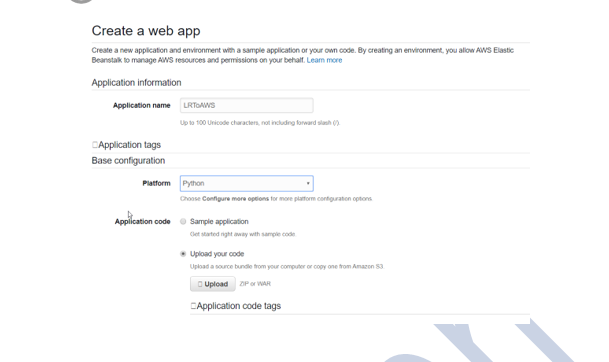

### Final Result:

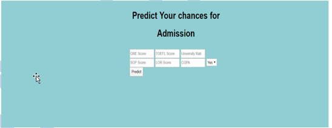